# Part II - Data_Explanatory

## Analysis for San Francisco Bay Ford GoBike Service 201902

## by Akubazgi Gebremariam

## Investigation Overview

I wanted to look at the characteristics or features of of Ford GoBike datast that could be used to improve bike service usage and identify the main users in the given time series datasets. To do this, the advanced python libraries are applied. Accordingly, insights are identified.

## Dataset Overview

This data set includes information about individual rides made in a bike-sharing system covering the greater San Francisco Bay area. The dataset contains arround 13 columns and latter some columns are added to make it more suitable for investigation. Some records associated with null values are removed because they were small in number. Handling datatype issue has benn alos made.

## Bike usage analysis interms of user type

The dataset contains 174952 of records in the 201902 given data. Almoss, most of the user type are Subscribers. The following shows the number of user type in percentage.

Thus most of the user types are permanent users who agrees to receive emails or notifications to use the bike ford company servies.

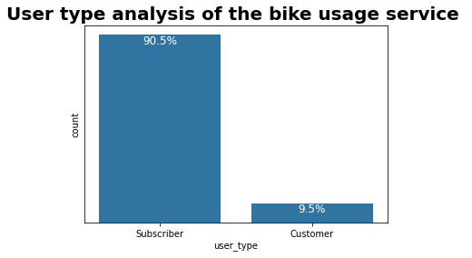

```python
plt.title(f'User type analysis of the bike usage service ', size=20, fontweight='bold')
VisualiseDf.plot_discriptive_count(df_bike_2019, df_bike_2019['user_type'])
```

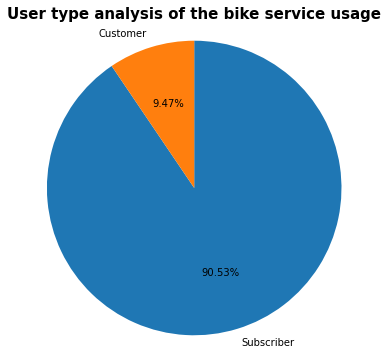

```python
# User type analysis using pie plot
def pie_plot(column:pd.DataFrame, title):
        plt.figure(figsize=(10,6))
        sorted_counts = column.value_counts()
        plt.pie(sorted_counts, labels = sorted_counts.index, startangle = 90,
                counterclock = False, autopct='%1.2f%%');
        plt.axis('square')
        #plt.legend('user_type')
        plt.title(title, fontsize=15, fontweight ='bold');

pie_plot(df_bike_2019['user_type'],'User type analysis of the bike service usage')
```

## Member gender analysis

- Most of the user are men in terms of gender
- Femle users of the bike service looks like small in number.

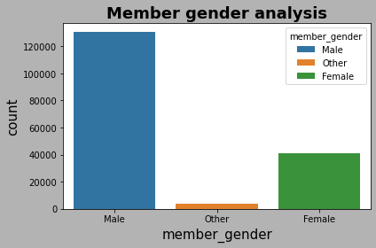

```python
# member gender analysis using countplot
ax = sb.countplot(x='member_gender', hue='member_gender', dodge=False, data=df_bike_2019)
ax.set_title('Member gender analysis', fontsize=18, fontweight='bold', color='black')
ax.set_xlabel('member_gender', fontsize=15, color='black')
ax.set_ylabel('count', fontsize=15, color='black')
ax.figure.set_facecolor('0.7')
plt.tight_layout()
plt.show()
```

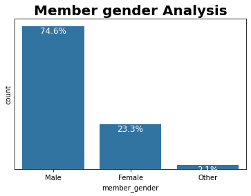

```python
# or using detailed statistical
plt.title(f'Member gender Analysis', size=20, fontweight='bold')
VisualiseDf.plot_discriptive_count(df_bike_2019,df_bike_2019['member_gender'] )
```

### Day wise Explanatory on each User type

> As we can see, almost the user types are subscribers and Thursday is the day in which both user type are widely using bike services.

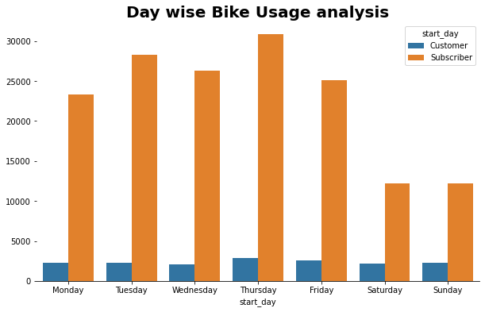

```python
#orders
days=["Monday","Tuesday","Wednesday","Thursday","Friday","Saturday","Sunday"]
# calling the plot function
VisualiseDf.bar_plot(df_bike_2019, 'start_day', days, 'user_type','Day wise Bike Usage analysis')
```

## Bike usage analysis in each Hour in relation to user type

> The following observation of this analysis are
> - The bike service usage at rush time(entring and leaving to and from work places) are mostly used by subscriber.
> - Similarly customer are also mostly using that time (rush time) comparing to other time slot.-

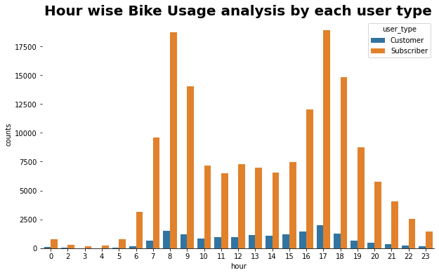

```python
# calling the barplot function
each_hour = [0,2,3,4,5,6,7,8,9,10,11,12,13,14,15,16,17,18,19,20,21,22,23] # order
bar_plot(df_bike_2019, 'hour', each_hour, 'user_type','Hour wise Bike Usage analysis by each user type')
```

### Analysis on the relationship among Catagorical varibles

Some of the catagorical I mostly intersted are included here.

> - Most of the subscribers are male
> - Most males use bike service on Thursday and Tuesday
> - Most females use bike service on same day as males
> - Thursday is the day mostly used for bike usage by the Subscribers(third plot).

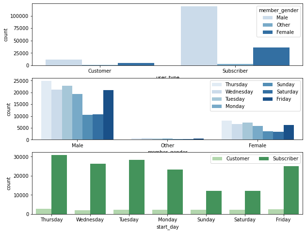

```python
# figuer size
plt.figure(figsize = [10, 8])

# subplot 1: user_type vs member_gender
plt.subplot(3, 1, 1)
sb.countplot(data = df_bike_2019, x = 'user_type', hue = 'member_gender', palette = 'Blues')

# subplot 2: member_gender vs start_day
ax = plt.subplot(3, 1, 2)
sb.countplot(data = df_bike_2019, x = 'member_gender', hue = 'start_day', palette = 'Blues')
ax.legend(ncol = 2)

# subplot 3: start_day vs user_type
ax = plt.subplot(3, 1, 3)
sb.countplot(data = df_bike_2019, x = 'start_day', hue = 'user_type', palette = 'Greens')
ax.legend(loc = 1, ncol = 2) # re-arrange legend to remove overlapping
#show
plt.show()
```

### Analysis on relationship among each day and duartion in relation to user type

Some interesting observation here

> - Duration usage on weekends is higher comparing to weekdays
> - Duration usage by Customers is higher than Subscribers
> - Sunday is the day which users take more duration in the bike usage. This could be, people may move far from home to spend time at the break day.

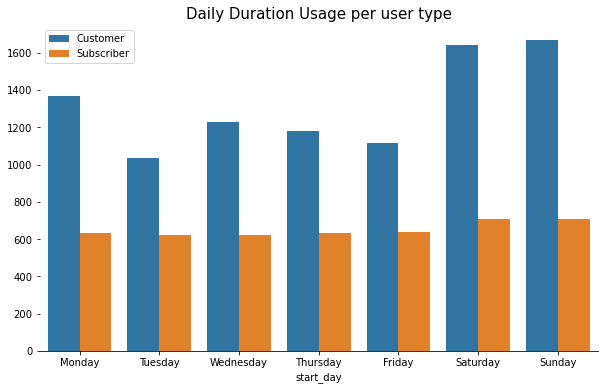

```python
# daily duration usage based on user type
def plot_multivariate():
    plt.figure(figsize=(10,6))
    plt.title('Daily Duration Usage per user type', fontsize=15)
    chart = sb.barplot(data=df_bike_2019, x='start_day', y='duration_sec', order=days, hue='user_type', ci=None)

    chart.set(xlabel='start_day', ylabel='')
    # Remove legend title
    sb.despine(fig=None, ax=None, top=True, right=True, left=True, bottom=False, offset=None, trim=False)
    plt.gca().legend().set_title('');

# clling
plot_multivariate()
```